# BKM

#### **From Raw to Civilized Data**

First I find the data from [BKM website](https://bkm.com.tr/secilen-aya-ait-sektorel-gelisim/?filter_year=2019&filter_month=1)I get the data of the last 6 months via rvest package. I will make a reproducible example of data analysis from the raw data located somewhere to the final analysis.

#### **Download Row Data**

I create two variables (url, page), then scraped the data from BKM website. To get the last 6 months, I use a for loop and change the filter in a specific range. I added a month column to dataframe and changed the column names lastly.

```r
library(rvest)
library(dplyr)
library(ggplot2)
library(scales)
library(plyr)

url <- "https://bkm.com.tr/secilen-aya-ait-sektorel-gelisim/?filter_year=2019&filter_month=1"
page <- read_html(url)
tablo <- html_table(page, fill = TRUE)[[4]][-c(1:2),]


for(i in 2:6) {
  url <- paste("https://bkm.com.tr/secilen-aya-ait-sektorel-gelisim/?filter_year=2019&filter_month=", i, sep = "")
  page <- read_html(url)
  tablo <- bind_rows(tablo, html_table(page, fill = TRUE)[[4]][-c(1:2),-1])
}

is_yeri <- c(tablo%>% select(X1) %>%  filter(X1 != "NA"))
is_yeri_1 <- c(rep(is_yeri[["X1"]], times=6))


tablo_1 <- tablo %>% mutate(X1 = is_yeri_1) %>% filter(X1 != "TOPLAM")


month_1 <- c(rep(1:6, times=1, each=26))
tablo_son <- tablo_1 %>% mutate(month = month_1)


tablo2  <- as.data.frame(lapply(tablo_son, function(x) as.numeric(gsub(",", ".", gsub("\\.", "", x)))))
tablo2[,1] <- tablo_son[,1]


colnames(tablo2) <- c("sector", "transaction_num_cc", "transaction_num_debit","transaction_amount_cc_mio", "transaction_amount_debit_mio", "month")

tablo_son <- tablo2
```

You can view head and tail of the dataset in below tables, respectively.

```r
head(tablo_son)
```

```
##                                   sector transaction_num_cc
## 1                         ARABA KIRALAMA             256372
## 2 ARAÇ KIRALAMA-SATIS/SERVIS/YEDEK PARÇA            2967019
## 3           BENZIN VE YAKIT ISTASYONLARI           25277186
## 4                     BIREYSEL EMEKLILIK            2271587
## 5                           ÇESITLI GIDA           28362091
## 6                     DOGRUDAN PAZARLAMA             757602
##   transaction_num_debit transaction_amount_cc_mio
## 1                 49296                    195.13
## 2                642136                   2185.84
## 3               8684036                   5066.04
## 4                   697                    716.42
## 5              15221891                   4473.98
## 6                 40038                    678.99
##   transaction_amount_debit_mio month
## 1                        14.77     1
## 2                       127.16     1
## 3                       680.01     1
## 4                         0.30     1
## 5                       673.70     1
## 6                         7.81     1
```

```r
tail(tablo_son)
```

```
##                                    sector transaction_num_cc
## 151        SEYAHAT ACENTELERI/TASIMACILIK            7224598
## 152                               SIGORTA            4513691
## 153                      TELEKOMÜNIKASYON           17915719
## 154 YAPI MALZEMELERI, HIRDAVAT, NALBURIYE            3786201
## 155                                 YEMEK           45687937
## 156                                 DIGER            4984660
##     transaction_num_debit transaction_amount_cc_mio
## 151               3152401                   2311.90
## 152                 42440                   2919.50
## 153               3236866                   1720.25
## 154               1347371                   2784.08
## 155              43035091                   2918.06
## 156               1072573                   1414.83
##     transaction_amount_debit_mio month
## 151                       620.16     6
## 152                        11.44     6
## 153                       247.08     6
## 154                       199.37     6
## 155                      1497.76     6
## 156                       170.06     6
```

#### **Analyses Related to BKM Dataset**

##### *Total Transaction Amount Comparision of All Sector | Jun 2019*

To see the share of sector in card payment business, I compare the sectors according to total transaction amount. I analyzed sectors that have more than 4000(mio) transaction volume individually and merge the other ones and named them “OTHER”. *“MARKET VE ALISVERIS MERKEZLERI”* is far ahead from other sectors with a share of 17.94%. There is a little competition for the second place but *“GIYIM VE AKSESUAR”* manage to get it ahead of *“BENZIN VE YAKIT ISTASYONLARI”*. Other 19 sectors have share of 39.93% combined.

```r
number1 = tablo_son %>% filter(month == 6) %>%
  transmute(sector, total_transaction_amount_mio = transaction_amount_cc_mio + transaction_amount_debit_mio) %>%
  arrange(desc(total_transaction_amount_mio)) %>%
  mutate(sector = case_when(total_transaction_amount_mio > 4000 ~ sector, TRUE ~ "OTHER")) %>% group_by(sector) %>%
  transmute(total_transaction_amount_mio = sum(total_transaction_amount_mio)) %>% distinct() %>%
  arrange(desc(total_transaction_amount_mio)) %>% ungroup() %>%
  mutate(share = round(total_transaction_amount_mio/sum(total_transaction_amount_mio)*100,2))

print(number1)
```

```
## # A tibble: 8 x 3
##   sector                               total_transaction_amount_mio share
##   <chr>                                                       <dbl> <dbl>
## 1 OTHER                                                      33935. 39.9
## 2 MARKET VE ALISVERIS MERKEZLERI                             15246. 17.9
## 3 GIYIM VE AKSESUAR                                           8246.  9.7
## 4 BENZIN VE YAKIT ISTASYONLARI                                7711.  9.07
## 5 ÇESITLI GIDA                                                6143.  7.23
## 6 HIZMET SEKTÖRLERI                                           4982.  5.86
## 7 YEMEK                                                       4416.  5.2
## 8 ELEKTRIK-ELEKTRONIK ESYA, BILGISAYAR                        4311.  5.07
```

You can see the pie chart that shows the distribution of the share.

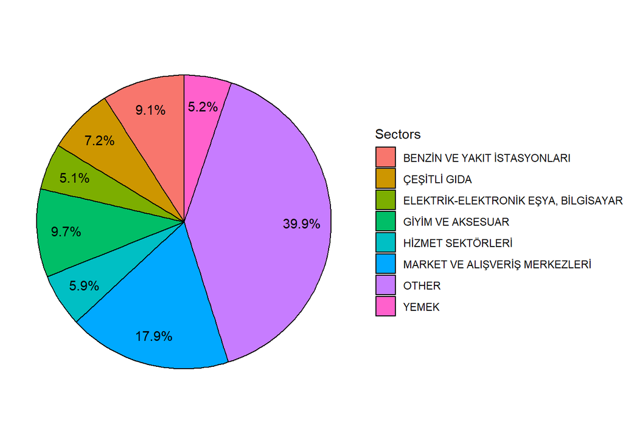

```r
number1 %>% ggplot(data = ., aes(x = "", y = share, fill = sector)) +
  geom_bar(width = 1, stat = "identity", color = "black") +
  coord_polar("y", start = 0)+
  geom_text(aes(x = 1.3, y = share, label = percent(share/100) ),position = position_stack(vjust = 0.5),color = "black")+
  labs(fill = "Sectors")+
  theme_void()
```

##### *Top 3 Companies Have The Biggest Transaction Number Change in 6 Months*

Beside the amount of transaction, number of transaction is another indicator that shows how much people are using their cards for payment. To demonstrate it, I analyzed the first half of 2019 and visualized changes of transaction numbers of top 3 companies according to difference of transaction numbers in 6 months. *“MARKET VE ALISVERIS MERKEZLERI”* has the biggest change in 6 months.

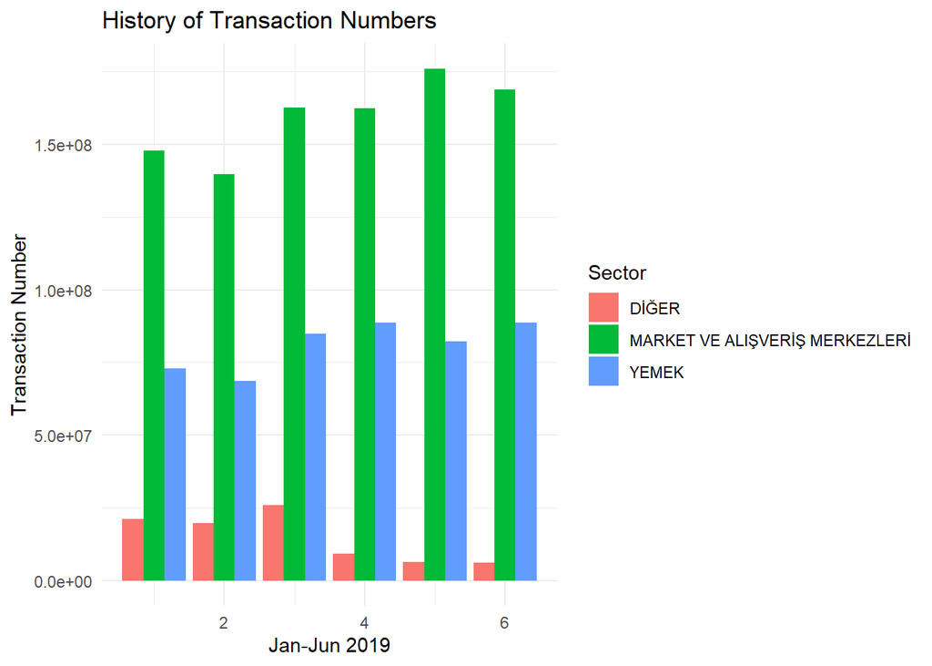

```r
library(ggplot2)
###
number2 <- tablo_son %>% filter(month %in% c(1,6)) %>% select(sector, transaction_num_cc, transaction_num_debit, month) %>%
  transmute(sector, total_transaction_num = transaction_num_cc+transaction_num_debit, month)

number2_1 <- number2[number2$month==1, ]
number2_6<- number2[number2$month==6, ]

number_all <- number2_1 %>% left_join(number2_6, by = "sector", suffix = c("_1","_6"))

top3 <- number_all %>% transmute(sector, transaction_difference = abs(total_transaction_num_6 - total_transaction_num_1)) %>%
  arrange(desc(transaction_difference)) %>% top_n(3) %>% select(sector)


top3_son <- top3 %>% left_join(tablo_son, by = "sector") %>% group_by(sector, month) %>%
  mutate(total_transaction = transaction_num_debit+transaction_num_cc) %>% select(sector, total_transaction, month)




top3_son %>% ggplot(data=., aes(x=month, y=total_transaction, fill=sector)) +
  geom_bar(stat="identity", position=position_dodge())+
  labs(x = "Jan-Jun 2019",y= "Transaction Number", title = "History of Transaction Numbers", fill= "Sector") +
  theme_minimal()
```